# Homework 4: Medical Expenditure Panel Survey

This is explanatory analysis of medical expenses related to medical treatments. This is a regression problem. In this work I trained and compared 2 models:

- Gradient Boosting Regressor
- Linear Regression

Data preprocessing was done and categorical variables were One Hot Encoded. Health Expenses were also limited to maximum of 150k$.

## 1. GradientBoostingRegressor

## 1.1 Selecting observations

In this part I am selecting 3 different observations for explanatory analysis for this model.

```python
predictions = (
    pd.DataFrame([y_pred_gbr, y_test])
    .T
    .rename(
        {
            0:"y",
            1:"y_pred"
        },
        axis=1
    )
)
predictions['diff'] = predictions['y'] - predictions['y_pred']
predictions['abs_diff'] = np.abs(predictions['diff'])
obs1_id = predictions.abs_diff.idxmin()
obs1 = predictions.iloc[obs1_id]
obs2_id = predictions['diff'].idxmin()
obs2 = predictions.iloc[obs2_id]
obs3_id = predictions['diff'].idxmax()
obs3 = predictions.iloc[obs3_id]
```

### 1.1.1 Obervation 1: Instance with minimum difference between prediction and predicted value

```python
obs1
```

```
y           0.055936
y_pred      0.000000
diff        0.055936
abs_diff    0.055936
Name: 823, dtype: float64
```

```python
X_test.iloc[obs1_id]
```

```
AGE31X                          42.00
PCS42                           53.17
MCS42                           54.96
K6SUM42                          4.00
INCOME_M                     49920.00
                               ...
POVCAT15_NEAR_POOR               0.00
POVCAT15_POOR_OR_NEGATIVE        0.00
INSCOV15_ANY_PRIVATE             0.00
INSCOV15_PUBLIC_ONLY             0.00
INSCOV15_UNINSURED               1.00
Name: 1516, Length: 143, dtype: float64
```

Here I have selected a patient with best predicted value of expenses, which differ by 0.05. Selected patient as an 42 years old patient with income of 50k.

```python
obs2
```

```
y            11431.247909
y_pred      136357.000000
diff       -124925.752091
abs_diff    124925.752091
Name: 1019, dtype: float64
```

```python
X_test.iloc[obs2_id]
```

```
AGE31X                          70.0
PCS42                           -1.0
MCS42                           -1.0
K6SUM42                         -1.0
INCOME_M                     16104.0
                              ...
POVCAT15_NEAR_POOR               0.0
POVCAT15_POOR_OR_NEGATIVE        0.0
INSCOV15_ANY_PRIVATE             1.0
INSCOV15_PUBLIC_ONLY             0.0
INSCOV15_UNINSURED               0.0
Name: 8883, Length: 143, dtype: float64
```

```python
obs3
```

```
y           33495.228721
y_pred        632.000000
diff        32863.228721
abs_diff    32863.228721
Name: 2893, dtype: float64
```

```python
X_test.iloc[obs3_id]
```

```
AGE31X                          75.00
PCS42                           14.08
MCS42                           51.49
K6SUM42                          3.00
INCOME_M                     47684.00
                               ...
POVCAT15_NEAR_POOR               0.00
POVCAT15_POOR_OR_NEGATIVE        0.00
INSCOV15_ANY_PRIVATE             0.00
INSCOV15_PUBLIC_ONLY             1.00
INSCOV15_UNINSURED               0.00
Name: 12577, Length: 143, dtype: float64
```

## 1.2 Explanations

```python
from ceteris_paribus.explainer import explain

explainer_gbr = explain(gbr, list(X_test.columns), X_test, y_test)
```

```
WARNING:root:Model is unlabeled...
 You can add label using method set_label
```

```python
from ceteris_paribus.profiles import individual_variable_profile

cp_profile = individual_variable_profile(explainer_gbr, X_test.iloc[obs2_id], y=obs2['y'])
```

```python
from ceteris_paribus.plots.plots import plot

plot(cp_profile, selected_variables=["INCOME_M"], inline=True)
```

[figure not shown]

Selected feature is the **INCOME_M** feature, which is a yearly income of some selected person.

Yearly income of the patient starts to influence the outcome of the model, when > 200k yearly. Below that value the cost stays almost the same. That means, that until the patient earns less then 200k a year, his medical expenses are around 15 1k, but if he starts to earn more, the medical expenses would rise to 18k+.

## 1.3. Finding two observations in the data set, such that they have different CP profiles

```python
explainer_gbr = explain(gbr, list(X_test.columns), X_test, y_test)
```

```
WARNING:root:Model is unlabeled...
 You can add label using method set_label
```

### 1.3.1 First observation

```python
x1 = sample.iloc[9]
x1
```

```
AGE31X                          50.0
PCS42                           -1.0
MCS42                           -1.0
K6SUM42                         -1.0
INCOME_M                     28766.0
                              ...
POVCAT15_NEAR_POOR               0.0
POVCAT15_POOR_OR_NEGATIVE        0.0
INSCOV15_ANY_PRIVATE             1.0
INSCOV15_PUBLIC_ONLY             0.0
INSCOV15_UNINSURED               0.0
Name: 9, Length: 143, dtype: float64
```

```python
cp_1 = individual_variable_profile(explainer_gbr, x1, variables=["AGE31X"])
plot(cp_1)
```

[figure not shown]

### 1.3.2 Second observation

```python
cp_2 = individual_variable_profile(explainer_gbr, sample.iloc[1], variables=["AGE31X"])
plot(cp_2)
```

[figure not shown]

### 1.3.3 Summary

For those two selected instances and feature **AGE31X** there is a difference in the influence on the model. For the first instance, when age is > 30 the costs drop, where for the second instance costs start to increase after age of 50.

Those two explanations for the selected observations differ in outcome, when age changes. In the first one age between 30 to 80 has the same expenses, while for the second observation expenses rise after age of 50. The cause of this might be thre influence of other variables on the model, other sicknesses or similar.

# 2. Comparing Gradient Boosting Regressor with Linear Regression Model

```python
explainer_slr = explain(slr, list(X_test.columns), X_test, y_test)
```

```
WARNING:root:Model is unlabeled...
 You can add label using method set_label
```

```python
cp_profile_slr = individual_variable_profile(explainer_slr, X_train.iloc[57], y=y_train.iloc[57])
plot(cp_profile_slr, selected_variables=["INCOME_M", "AGE31X"], inline=True)
```

[output not shown]

## 2.1 Selecting and observation for which the models differ

```python
X_train.iloc[57]
```

```
AGE31X                       13.0
PCS42                        -1.0
MCS42                        -1.0
K6SUM42                      -1.0
INCOME_M                      0.0
                             ...
POVCAT15_NEAR_POOR            0.0
POVCAT15_POOR_OR_NEGATIVE     0.0
INSCOV15_ANY_PRIVATE          1.0
INSCOV15_PUBLIC_ONLY          0.0
INSCOV15_UNINSURED            0.0
Name: 15780, Length: 143, dtype: float64
```

## 2.2 Linear Regression

For this selected observation and linear regression model, the explanation is that the expenses don't change when **INCOME_M** or **AGE31X** changes. The reason for this might be the influence of other variables on the model outcome.

## 2.3 Gradient Boosting Regression

[figure not shown]

For the selected observation variable **INCOME_M** influences the model prediction, when the income is greater than 150k a year, the predicted cost rises from around 2k to almost 7k and more. With the increase of **AGE31x** after 50 the predicted cost also rises from 2k to 5k.

## 2.4 Summary

For this instance the influence of features **INCOME_M** and **AGE31X** is different between models. For Linear Regression there is no influence on the result, but for Gradient Boosting Regressor there is influence of those features on the predicted outcome. The reason for this might be how the two models learn and which variables the take into account when making predictions. For Linear Regression the outcome of the model does not change, while for Gradient Boosting Regressor they influence the outcome of the model. An argument behind it could be, that the selected patient is a child of age 13 with no income, so one model could have learned this, while the other not.

# Appendix

```python
%matplotlib inline

import numpy as np
import matplotlib.pyplot as plt
import pandas as pd
import tensorflow as tf
import seaborn as sns

from sklearn.model_selection import train_test_split
from sklearn.metrics import r2_score
from sklearn.linear_model import LinearRegression
from sklearn.ensemble import GradientBoostingRegressor
from sklearn.model_selection import train_test_split
from aix360.datasets import MEPSDataset


from dalex import explainer


pd.options.display.max_columns = 45
```

```python
data = MEPSDataset().data()
```

```python
data.reset_index(drop=True, inplace=True)
```

```python
data.drop(columns= ['PANEL', 'PERSONWT'], inplace=True)
```

```python
data = data[data['HEALTHEXP'] < 150000]
```

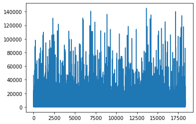

```python
plt.plot(data.HEALTHEXP)
```

```python
data.head()
```

|  | REGION | AGE31X | GENDER | RACE3 | MARRY31X | EDRECODE | FTSTU31X | ACTDTY31 | HONRDC31 | RTHLTH31 | MNHLTH31 | HIBPDX | CHDDX | ANGIDX | MIDX | OHRTDX | STRKDX | EMPHDX | CHBRON31 | CHOLDX | CANCERDX | DIABDX | JTPAIN31 | ARTHDX | ARTHTYPE | ASTHDX | ADHDADDX | PREGNT31 | WLKLIM31 | … |
| --- | --- | --- | --- | --- | --- | --- | --- | --- | --- | --- | --- | --- | --- | --- | --- | --- | --- | --- | --- | --- | --- | --- | --- | --- | --- | --- | --- | --- | --- | --- |
| 0 | 2 | 52 | 0.0 | 0.0 | 5 | 13 | -1 | 2 | 2 | 4 | 1 | 1 | 1 | 1 | 1 | 1 | 2 | 1 | 2 | 1 | 2 | 1 | 1 | 1 | 3 | 2 | -1 | -1 | 1 | … |
| 1 | 2 | 55 | 1.0 | 0.0 | 3 | 14 | -1 | 2 | 2 | 4 | 1 | 1 | 2 | 2 | 2 | 2 | 2 | 2 | 2 | 1 | 2 | 1 | 2 | 1 | 3 | 1 | -1 | -1 | 1 | … |
| 2 | 2 | 22 | 1.0 | 0.0 | 5 | 13 | 3 | 2 | 2 | 1 | 1 | 2 | 2 | 2 | 2 | 2 | 2 | 2 | 2 | 2 | 2 | 2 | 2 | 2 | -1 | 2 | -1 | 2 | 2 | … |
| 3 | 2 | 2 | 0.0 | 0.0 | 6 | -1 | -1 | 3 | 3 | 1 | 1 | -1 | -1 | -1 | -1 | -1 | -1 | -1 | -1 | -1 | -1 | -1 | -1 | -1 | -1 | 2 | -1 | -1 | 2 | … |
| 4 | 3 | 25 | 1.0 | 0.0 | 1 | 14 | -1 | 2 | 2 | 1 | 3 | 2 | 2 | 2 | 2 | 2 | 2 | 2 | 2 | 2 | 2 | 2 | 1 | 2 | -1 | 2 | -1 | 1 | 2 | … |

```python
def score_r2_print(clf, X_train, X_test, y_train, y_test):
    print('Training R^2:', r2_score(y_train, clf.predict(X_train)))
    print('Test R^2:', r2_score(y_test, clf.predict(X_test)))
```

# Data preprocessing

```python
cols = data.columns
```

```python
categoricalCols = [
    'REGION','GENDER', 'RACE3', 'MARRY31X','EDRECODE','FTSTU31X','ACTDTY31','HONRDC31',
    'RTHLTH31','MNHLTH31','HIBPDX','CHDDX','ANGIDX','MIDX','OHRTDX','STRKDX','EMPHDX',
    'CHBRON31','CHOLDX','CANCERDX','DIABDX','JTPAIN31','ARTHDX', 'ARTHTYPE','ASTHDX',
    'ADHDADDX','PREGNT31','WLKLIM31','ACTLIM31','SOCLIM31','COGLIM31','DFHEAR42',
    'DFSEE42','ADSMOK42','PHQ242','EMPST31','POVCAT15','INSCOV15'
]
```

```python
X, y = data.drop({'HEALTHEXP'}, 1), data['HEALTHEXP']
```

```python
X_cat = X.copy()
for cat in categoricalCols:
    X_cat[cat] = X_cat[cat].astype('category')
```

```python
X_copied = X.copy()
X_copied['REGION'] = X_copied['REGION'].map({i: 'REGION_' + str(i) for i in range(1, 5)})
X_copied['MARRY31X'] = X_copied['MARRY31X'].map({i: 'MARRY31X_' + str(i) for i in range(1, 11)})
X_copied['GENDER'] = X_copied['GENDER'].map({0: 'MALE', 1: 'FEMALE'})
X_copied['RACE3'] = X_copied['RACE3'].map({0: 'RACE_0', 1: 'RACE_1'})
X_copied['EDRECODE'] = X_copied['EDRECODE'].map({-1: "EDRECODE_INAPPLICABLE", 1: 'EDRECODE_LSEQ_8TH_GRADE', 2: 'EDRECODE_9-12TH_GRAD', 13: 'EDRECODE_GED_OR_GRAD', 14:'EDRECODE_BEYOND_HS_OR_COLLEGE', 15: 'EDRECODE_BACHELOR', 16: 'EDRECODE_HIGHER_DEGREE'})
X_copied['FTSTU31X'] = X_copied['FTSTU31X'].map({-1: 'FTSTU31X_INAPPLICABLE', 1: 'FTSTU31X_FULLTIME', 2: 'FTSTU31X_PARTTIME', 3: 'FTSTU31X_NOT_A_STUDENT'})
X_copied['ACTDTY31'] = X_copied['ACTDTY31'].map({-1: 'ACTDTY31_INAPPLICABLE', 1: 'ACTDTY31_YES', 2 : "ACTDTY31_NO", 3: 'ACTDTY31_INAPPLICABLE_UNDER_16', 4: 'ACTDTY31_INAPPLICABLE_OVER_59'})
X_copied['HONRDC31'] = X_copied['HONRDC31'].map({-1: 'HONRDC31_INAPPLICABLE', 1: 'HONRDC31_YES', 2 : "HONRDC31_NO", 3: 'HONRDC31_INAPPLICABLE_UNDER_16', 4: 'HONRDC31_ACTIVE_DUTY'})
X_copied['ARTHTYPE'] = X_copied['ARTHTYPE'].map({-1: 'ARTHTYPE_INAPPLICABLE', 1: 'ARTHTYPE_RHEUMATOID_ARTHRITIS', 2 : "ARTHTYPE_OSTEOARTHRITIS", 3: 'ARTHTYPE_NOT_SPECIFIED'})
X_copied['POVCAT15'] = X_copied['POVCAT15'].map({ 1: 'POVCAT15_POOR_OR_NEGATIVE', 2 : "POVCAT15_NEAR_POOR", 3: 'POVCAT15_LOW_INCOME', 4: 'POVCAT15_MIDDLE_INCOME', 5: 'POVCAT15_HIGH_INCOME'})
X_copied['INSCOV15'] = X_copied['INSCOV15'].map({1: 'INSCOV15_ANY_PRIVATE', 2: 'INSCOV15_PUBLIC_ONLY', 3: 'INSCOV15_UNINSURED'})


for cat in ['RTHLTH31', 'MNHLTH31', 'PHQ242', 'EMPST31']:
    X_copied[cat] = X_copied[cat].map({i: cat + '_' + str(i) for i in range(1, 7)})


for cat in ['HIBPDX', 'CHDDX', 'ANGIDX', 'MIDX', 'OHRTDX', 'STRKDX', 'EMPHDX',
            'CHBRON31', 'CHOLDX', 'CANCERDX', 'DIABDX', 'JTPAIN31', 'ARTHDX',
            'ASTHDX', 'ADHDADDX', 'PREGNT31', 'WLKLIM31', 'ACTLIM31',
            'SOCLIM31', 'COGLIM31', 'DFHEAR42', 'DFSEE42', 'ADSMOK42']:
    X_copied[cat] = X_copied[cat].map({-1: cat + "_INAPPLICABLE", 1: cat + "_YES", 2 : cat + "_NO"})

X_copied = pd.get_dummies(X_copied, prefix='', prefix_sep='')
```

```python
X_copied.head()
```

|  | AGE31X | PCS42 | MCS42 | K6SUM42 | INCOME_M | REGION_1 | REGION_2 | REGION_3 | REGION_4 | FEMALE | MALE | RACE_0 | RACE_1 | MARRY31X_1 | MARRY31X_10 | MARRY31X_2 | MARRY31X_3 | MARRY31X_4 | MARRY31X_5 | MARRY31X_6 | MARRY31X_7 | MARRY31X_8 | ... | DFSEE42_YES | ADSMOK42_INAPPLICABLE | ADSMOK42_NO | ADSMOK42_YES | PHQ242_1 | PHQ242_2 | … |
| --- | --- | --- | --- | --- | --- | --- | --- | --- | --- | --- | --- | --- | --- | --- | --- | --- | --- | --- | --- | --- | --- | --- | --- | --- | --- | --- | --- | --- | --- | --- |
| 0 | 52 | 25.93 | 58.47 | 3 | 11390.0 | 0 | 1 | 0 | 0 | 0 | 1 | 1 | 0 | 0 | 0 | 0 | 0 | 0 | 1 | 0 | 0 | 0 | ... | 0 | 0 | 1 | 0 | 0 | 0 | … |
| 1 | 55 | 20.42 | 26.57 | 17 | 11390.0 | 0 | 1 | 0 | 0 | 1 | 0 | 1 | 0 | 0 | 0 | 0 | 1 | 0 | 0 | 0 | 0 | 0 | ... | 0 | 0 | 1 | 0 | 0 | 0 | … |
| 2 | 22 | 53.12 | 50.33 | 7 | 18000.0 | 0 | 1 | 0 | 0 | 1 | 0 | 1 | 0 | 0 | 0 | 0 | 0 | 0 | 1 | 0 | 0 | 0 | ... | 0 | 0 | 1 | 0 | 0 | 0 | … |
| 3 | 2 | -1.00 | -1.00 | -1 | 385.0 | 0 | 1 | 0 | 0 | 0 | 1 | 1 | 0 | 0 | 0 | 0 | 0 | 0 | 0 | 1 | 0 | 0 | ... | 0 | 1 | 0 | 0 | 0 | 0 | … |
| 4 | 25 | 59.89 | 45.91 | 9 | 3700.0 | 0 | 0 | 1 | 0 | 1 | 0 | 1 | 0 | 1 | 0 | 0 | 0 | 0 | 0 | 0 | 0 | 0 | ... | 0 | 0 | 1 | 0 | 0 | 1 | … |

5 rows × 143 columns

```python
X_train, X_test, y_train, y_test = train_test_split(X_copied, y, test_size=0.2, random_state=37)
```

# 1 Training models

## 1.1. Linear Regression

```python
slr = LinearRegression()
```

```python
slr.fit(X_train, y_train)
```

```
LinearRegression(copy_X=True, fit_intercept=True, n_jobs=None, normalize=False)
```

```python
score_r2_print(slr, X_train, X_test, y_train, y_test)
```

```
Training R^2: 0.24469433693454268
Test R^2: 0.19099338340802963
```

```python
y_test_pred = slr.predict(X_test)
y_train_pred = slr.predict(X_train)
```

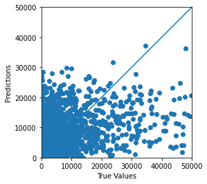

```python
a = plt.axes(aspect='equal')
plt.scatter(y_test, y_test_pred)
plt.xlabel('True Values')
plt.ylabel('Predictions')
lims = [0, 50000]
plt.xlim(lims)
plt.ylim(lims)
_ = plt.plot(lims, lims)
```

## 1.2. Ridge Regression

```python
from sklearn.linear_model import Ridge
```

```python
ridge = Ridge(alpha=1.0)
ridge.fit(X_train, y_train)
score_r2_print(ridge, X_train, X_test, y_train, y_test)
```

```
Training R^2: 0.24466621634861008
Test R^2: 0.19144151129170606
```

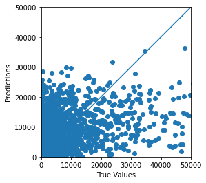

```python
a = plt.axes(aspect='equal')
plt.scatter(y_test, ridge.predict(X_test))
plt.xlabel('True Values')
plt.ylabel('Predictions')
lims = [0, 50000]
plt.xlim(lims)
plt.ylim(lims)
_ = plt.plot(lims, lims)
```

## 1.3. RandomForestRegressor

```python
from sklearn.ensemble import RandomForestRegressor

tree = RandomForestRegressor(
    n_estimators=900,
    criterion='mse',
    random_state=1,
    max_features="sqrt",
    n_jobs=-1)
tree.fit(X_train, y_train)
score_r2_print(tree, X_train, X_test, y_train, y_test)
```

```
Training R^2: 0.8927740400077464
Test R^2: 0.18285282491194998
```

## 1.4 Gradient Boosting Regressor

```python
gbr = GradientBoostingRegressor(n_estimators=200, random_state=7, max_features="log2")
gbr.fit(X_train, y_train)

score_r2_print(gbr, X_train, X_test, y_train, y_test)
```

```
Training R^2: 0.32441228606427686
Test R^2: 0.20092095634569807
```

```python
y_pred_gbr = gbr.predict(X_test)
```

```python
test_predictions = gbr.predict(X_test)
```

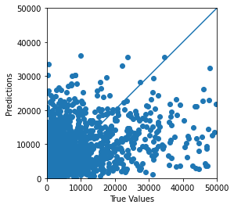

```python
a = plt.axes(aspect='equal')
plt.scatter(y_test, test_predictions)
plt.xlabel('True Values')
plt.ylabel('Predictions')
lims = [0, 50000]
plt.xlim(lims)
plt.ylim(lims)
_ = plt.plot(lims, lims)
```